# Using Social Network Analysis to Lessen the Risk of Churning

### Using Social Network Analysis to Lessen the Risk of Churning

#### Quick Introduction

An employee has a freedom to decide whether they will stay or leave the company. Employee churning have different factors affecting their decision making, for instance, work environment, company resources, salary, distance from home, organization competitors and many more. Occurence of employee churn is a huge problem for most organizations because it may cause a negative impact to the company.

Many business organizations utilize social media platform where they can quickly and easily post a relevant announcements to all, send an important message to different co-workers that belong to distinct departments and interact with other employees by liking, commenting, and sharing their post. This could also help the company to boost their productivity by making this as a collaboration tool to help them work together more efficiently.

In this notebook, we will analyze the cause of employee churn through the use of Social Network Analysis (SNA), it is a method used for investigating the social structures, which is under of graph theory. The data used in this blog was already cleaned and scraped from the social media platform; **Workplace**, it is a work collaboration platform and intended only for enterprise. In addition, it was developed by Facebook Inc., which has a similar functionalities from Facebook. For more information about workplace visit this [Link](https://www.facebook.com/workplace/about).

Let's get started!

### Data Description

In this notebook, we'll used two datasets namely; `churn data` and `post with reactions data`.

#### Churn Data

`churn data` is a data for the total employees did churned and retained. For security reason, I didn't include the personal information of each employee as well as the source of this data. Please note that the column `id` was already scraped from Workplace through Facebook Graph API. Let me know if you've question about data scraping, just send me an email ricardo.calura29@gmail.com. Anyway, here are the columns' name and description:

- id - represent the unique identifier for their workplace account
- hire_date - the date when the employee hired
- position - current role of the employee in the company
- career_level - level of the employee position, higher number equivalent to higher position
- department - department where the employee belong
- tenure - how long did the employee work in the company
- status - employee status, 1 for retain and 0 for churn

Now, read the data and observe its structures.

|  | id | hire_date | position | career_level | department | tenure | status |
| --- | --- | --- | --- | --- | --- | --- | --- |
| 0 | 100032953145639 | January 11, 2016 | Project Manager | 5 | Project Management Office | 3.03 | 1 |
| 1 | 100032861410766 | August 23, 2017 | Project Manager | 5 | Project Management Office | 1.39 | 1 |
| 2 | 100032906108046 | November 16, 2011 | Technical Manager | 5 | Software Engineering Group | 7.20 | 1 |
| 3 | 100033012390854 | January 2, 2018 | Scrum Master Manager | 5 | Project Management Office | 1.10 | 1 |
| 4 | 100032731670581 | October 9, 2018 | Sr. Software Engineer | 2 | Software Engineering Group | 0.29 | 1 |

```
(294, 7)
```

We have a total of 294 employees including the employee that churned.

#### Post With Reactions Data

The next data is `post with reactions data`. Similar with column `id` from `churn data`, this data was also scraped from Workplace. It consists of several posts made by user as well as the total accumulated reactions by that post. These are the few description about the data.

- group_id - unique identifier for the group where post belong
- post_id - unique identifier for the post
- poster_id - unique identifer for the owner of the post
- updated_time - date and time it was posted
- reactions - total reaction received by the post. (this field is in dictionary format where the key represent the unique identifier for employee and the value for corresponding reaction)

|  | group_id | post_id | poster_id | updated_time | reactions |
| --- | --- | --- | --- | --- | --- |
| 0 | 1353879364788125 | 1353879371454791 | 100032815874121 | 2019-08-16T12:10:40+0000 | {} |
| 1 | 2595968997101362 | 2757134047651522 | 100032876165558 | 2019-11-04T23:20:15+0000 | {} |
| 2 | 2595968997101362 | 2595969007101361 | 100032876165558 | 2019-08-16T10:53:44+0000 | {} |
| 3 | 485060002294083 | 540607426739340 | 100036201673274 | 2019-11-05T02:04:37+0000 | {'100032633731654': 'LIKE'} |
| 4 | 485060002294083 | 533029284163821 | 100036201673274 | 2019-10-28T00:25:33+0000 | {} |

```
(1872, 5)
```

A total of 1872 posts are created by the workers.

#### Why do we need these two data?

In order to formulate a graph, we need to think of vertices and edges first (some of the textbooks they refer vertices as nodes and edges as links). In this case, our vertices will be the employees who have Workplace account. While the edges are the connections between the two employees who either give reactions to the post or receive reactions from his own post. Example, supposed I've share something about machine learning and my co-worker Benjamin liked it, and then the connection between me and Benjamin are created, if you like other post or received a like from other co-workers, connection will established. Thus, we need these two data because we are going to mapped the status of the employees (`churn data`) to their activities and engagement in Workplace (`post with reactions data`).

Now, let's proceed building the graph!

Create an emtpy directed graph then add the vertices and edges. Remember that the `vertices` are the employees, and `edges` are the employees who reacted to the post.

```
11263 edges added to the graph
```

### Initial Graph

Upon adding vertices and edges to the graph, we can now start visualizing the graph.

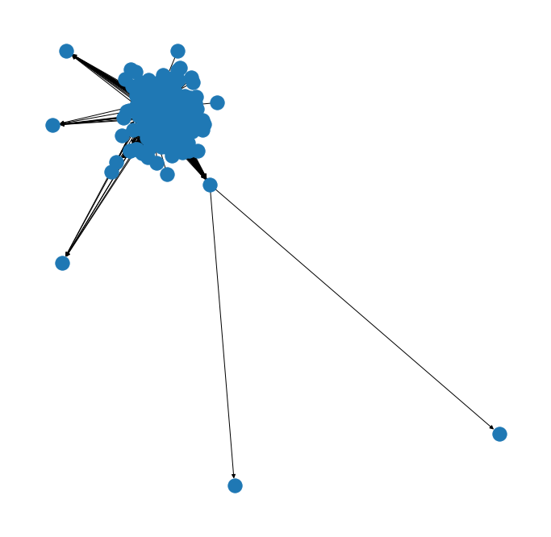

After observing, the vertices seems concentrated at the center of the graph. Basically, the centered-vertices had collected more edges than to the outered-vertices. The vertices with lower amount of edges implies less interaction while more edges represent more interactions. However, vertices without edges (simply called isolated vertices) represent the users who didn't create and share any post and at the same time didn't give any reactions to other co-workers' post. This graph doesn't make sense at first since our goal is to determine the reason of churning. Now, let's dive deeper by combining the `churn data` to the graph.

Note: Isolated vertices aren't included in the graph yet.

### Pre-processing

Not all of the workers in the dataset have workplace profile, so they are useless since this blog is intended only for investigating the anatomy of organization's social media platform. To address the problem, just simply remove them.

```
12 employees have been successfully removed
Total number of employee did churned is 38 and 243 for retained
```

### Final Graph

Incorporate `churn data` to previously created graph. Also, add the isolated vertices because this will help us to our final analysis.

For retain list:

```
14 isolated nodes added to the graph
```

For churn list:

```
14 isolated nodes added to the graph
```

After adding the isolated vertices, start to visualize the graph again. Please note that I did some modification on graph just to inhibit the overlapping of vertices. And this is done by using and getting the optimal value for `k` parameter. For more information read this [documentation](https://networkx.github.io/documentation/networkx-1.9/reference/generated/networkx.drawing.layout.spring_layout.html).

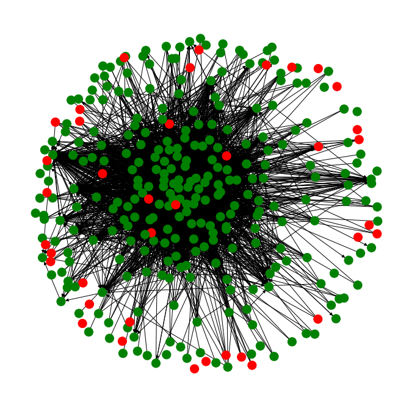

This is the final graph. Basically, red nodes represent the employees who churned and green nodes for the employees who retained in the company. Upon investigating, mostly of the employees that churned are position at the outer portion of the graph. This make sense because as we remember, outered-vertices implies less-edges vertices, or employees who did not interact well. Thus, we can say that employee churning most often when employee did not engage well in Workplace.

### Degree Distribution

#### Outgoing-Degree

To verify our analysis, let's count the number of outgoing-degree for each vertex. Please note that the outgoing-degree is established when the worker react to other co-workers' post. So, if the employee has no outgoing-degree it means that he/she didn't reacted to any post.

```
Out of 38 employees who resigned, 15 of them haven't reacted to any post
```

```
Out of 243 employees who retain, 16 of them haven't reacted to any post
```

[output not shown]

| Total Churned Employee | Total Employee Without Reaction Given | Percentage |
| --- | --- | --- |
| 38 | 15 | 39.474% |

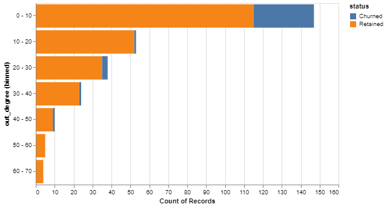

For much precise result, here is the `outgoing-degree` distribution for both churned and retained employees. As we notice above,

- Less probability of churning when employees giving more likes and reactions to other colleagues.
- More employees did churned at bin outdegree `0-10`.

#### Ingoing-Degree

In-going degree is a directed link where the arrow-head pointing in to the node. In this case, in-going degree is linked when the employee received reactions from her post. Higher number of in-going degree, more reactions the employee collected.

```
Out of 38 employees who churned, 34 of them did not recieved any reactions
```

```
Out of 243 employees who retain, 138 of them did not recieved any reactions
```

| Total Retained Employee | Total Employee Without Reaction Received | Percentage |
| --- | --- | --- |
| 243 | 138 | 56.79% |

| Total Churned Employee | Total Employee Without Reaction Received | Percentage |
| --- | --- | --- |
| 38 | 34 | 89.47% |

Almost all of the employees who resigned didn't received any reactions from his co-workers. I think these are the possible reasons, these employees might;

- Not interested to share and post something
- Working solely

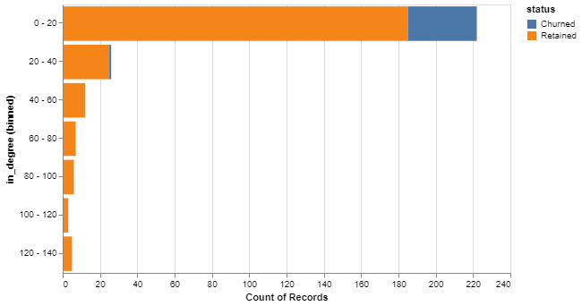

Distribution of `ingoing-degree` is shown above. The useful insights are:

- This distribution proved that almost all of the workers did resgined haven't received any likes and reactions.
- Less prone of churning when employees received higher amount of reactions.

### Conclusion

The analysis shows us that employees churning usually happened when they're not engaging well in Workplace. Even there are many other factors needed to consider, we must still need to account the interactions of each employee from using social media. So what are you waiting for? Try and make use of this kind of data, by doing the same analysis (`Social Network Analysis`). If you're a data scientist, data analyst, this insight might help your organization to lessen the risk of churning.

I'm looking forward to do more by implementing `Weighted Directed Graph` which would put weights in repeating connections (liking several posts of the same employee) because the one currently presented establishes a connection if a person liked another person's post but not taking into account succeeding connections which weights would account for.

On the other hand, for the next step, we could do predictive analytics to simply predict the employees that risk of churning. In this way, we could help the Human Resources to reduce the employee turnover, and improved their employee retention strategies.

Let me know if you've questions. Just leave a message here ricardo.calura29@gmail.com

Thank you for reading!